# CMSC 320 Final Project

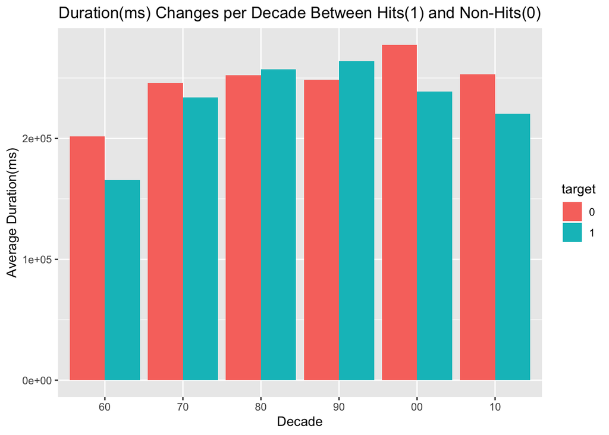

```r
plot_avg_by_decade <- function(df,col){

  plotting <- df %>%
    group_by(decade,target) %>%
    summarise(avg=mean({{col}})) %>%
    mutate(target=as.factor(target))

  ggplot(plotting) +
    geom_bar(stat="identity", aes(x=decade,y = avg,fill=target), position ="dodge") +
    labs(title = "Duration(ms) Changes per Decade Between Hits(1) and Non-Hits(0)", x = "Decade", y = "Average Duration(ms)") +
    theme(plot.title = element_text(hjust = 0.5))
}

song_df %>%
  plot_avg_by_decade(duration_ms)
```

duration

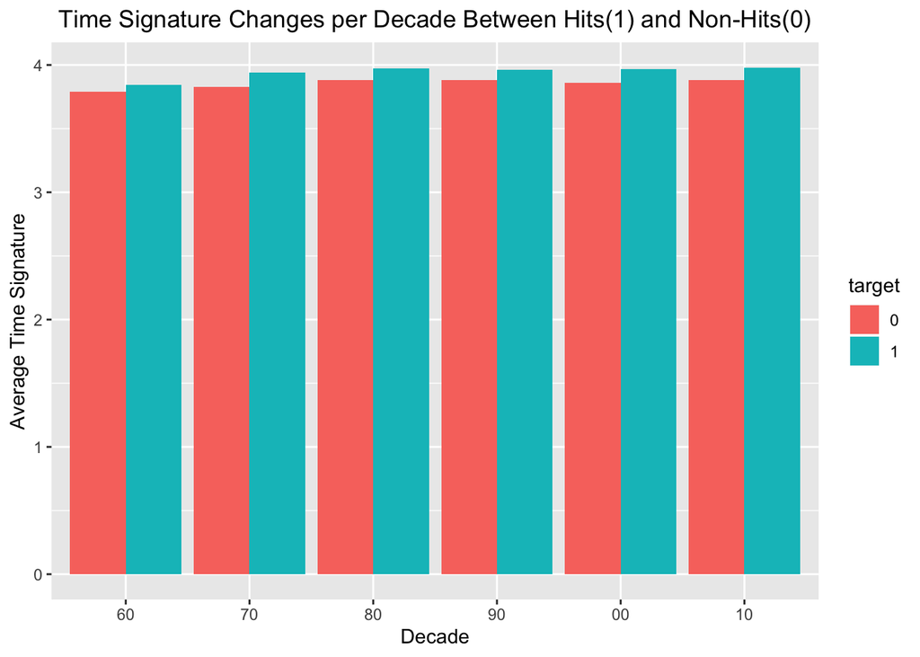

```r
plot_avg_by_decade <- function(df,col){

  plotting <- df %>%
    group_by(decade,target) %>%
    summarise(avg=mean({{col}})) %>%
    mutate(target=as.factor(target))

  ggplot(plotting) +
    geom_bar(stat= "identity",aes(x=decade,y = avg,fill=target),position = "dodge") +
    labs(title = "Time Signature Changes per Decade Between Hits(1) and Non-Hits(0)", x = "Decade", y = "Average Time Signature") +
    theme(plot.title = element_text(hjust = 0.5))
}

song_df %>%
  plot_avg_by_decade(time_signature)
```

time signature

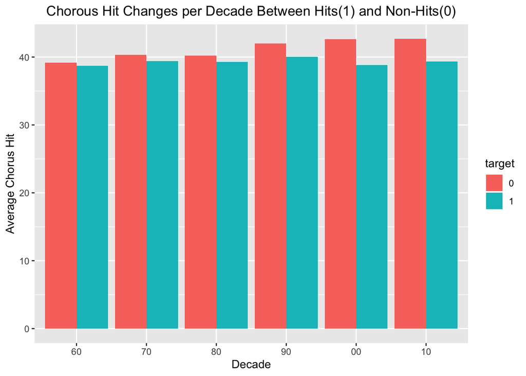

```r
plot_avg_by_decade <- function(df,col){

  plotting <- df %>%
    group_by(decade,target) %>%
    summarise(avg=mean({{col}})) %>%
    mutate(target=as.factor(target))

  ggplot(plotting) +
    geom_bar(stat="identity", aes(x=decade,y = avg,fill=target), position="dodge") +
    labs(title = "Chorous Hit Changes per Decade Between Hits(1) and Non-Hits(0)", x = "Decade", y = "Average Chorus Hit") +
    theme(plot.title = element_text(hjust = 0.5))
}

song_df %>%
  plot_avg_by_decade(chorus_hit)
```

chorus

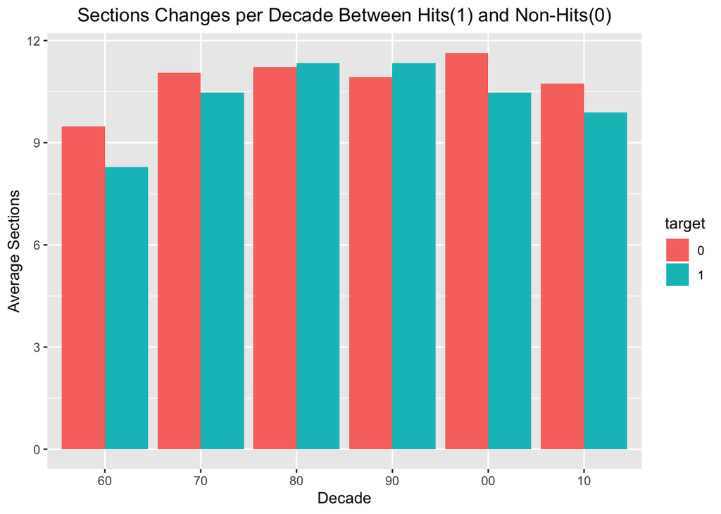

```r
plot_avg_by_decade <- function(df,col){

  plotting <- df %>%
    group_by(decade,target) %>%
    summarise(avg=mean({{col}})) %>%
    mutate(target=as.factor(target))

  ggplot(plotting) +
    geom_bar(stat="identity", aes(x=decade,y = avg,fill=target), position = "dodge") +
    labs(title = "Sections Changes per Decade Between Hits(1) and Non-Hits(0)", x = "Decade", y = "Average Sections") +
    theme(plot.title = element_text(hjust = 0.5))
}

song_df %>%
  plot_avg_by_decade(sections)
```

sections

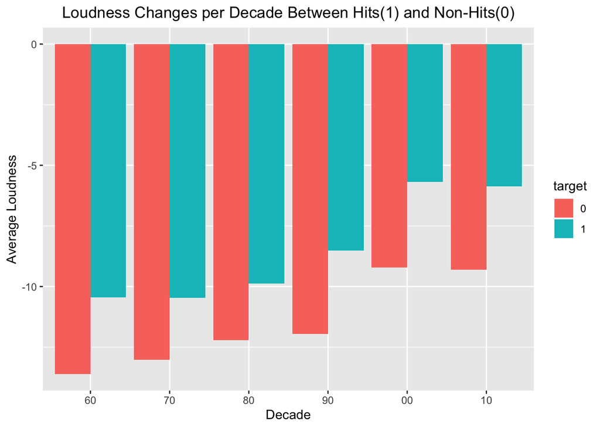

```r
plot_avg_by_decade <- function(df,col){

  plotting <- df %>%
    group_by(decade,target) %>%
    summarise(avg=mean({{col}})) %>%
    mutate(target=as.factor(target))

  ggplot(plotting) +
    geom_bar(stat="identity", aes(x=decade,y = avg,fill=target), position="dodge") +
    labs(title = "Loudness Changes per Decade Between Hits(1) and Non-Hits(0)", x = "Decade", y = "Average Loudness") +
    theme(plot.title = element_text(hjust = 0.5))
}

song_df %>%
  plot_avg_by_decade(loudness)
```

loudness

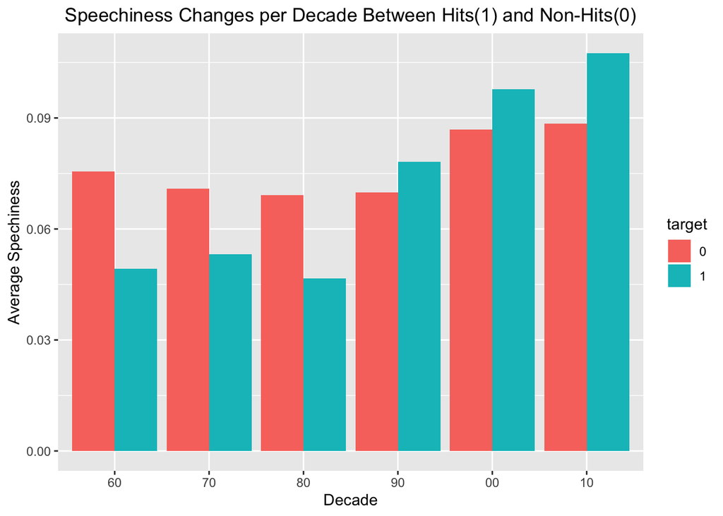

```r
plot_avg_by_decade <- function(df,col){

  plotting <- df %>%
    group_by(decade,target) %>%
    summarise(avg=mean({{col}})) %>%
    mutate(target=as.factor(target))

  ggplot(plotting) +
    geom_bar(stat= "identity",aes(x=decade,y = avg,fill=target),position = "dodge") +
    labs(title = "Speechiness Changes per Decade Between Hits(1) and Non-Hits(0)", x = "Decade", y = "Average Spechiness") +
    theme(plot.title = element_text(hjust = 0.5))
}

song_df %>%
  plot_avg_by_decade(speechiness)
```

speechness

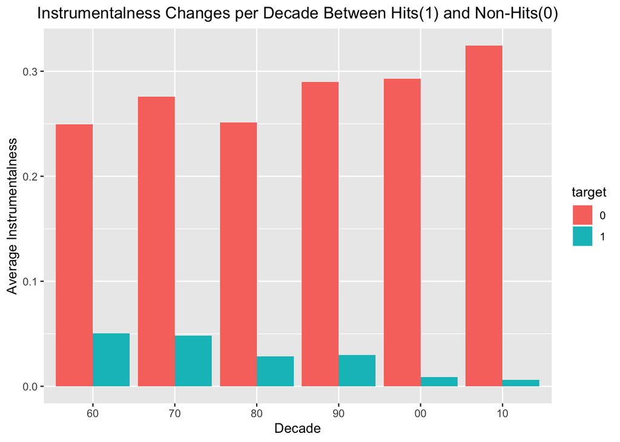

```r
plot_avg_by_decade <- function(df,col){

  plotting <- df %>%
    group_by(decade,target) %>%
    summarise(avg=mean({{col}})) %>%
    mutate(target=as.factor(target))

  ggplot(plotting) +
    geom_bar(stat="identity", aes(x=decade,y = avg,fill=target), position="dodge") +
    labs(title = "Instrumentalness Changes per Decade Between Hits(1) and Non-Hits(0)", x = "Decade", y = "Average Instrumentalness") +
    theme(plot.title = element_text(hjust = 0.5))
}

song_df %>%
  plot_avg_by_decade(instrumentalness)
```

intstrumentalness how many artists have hits

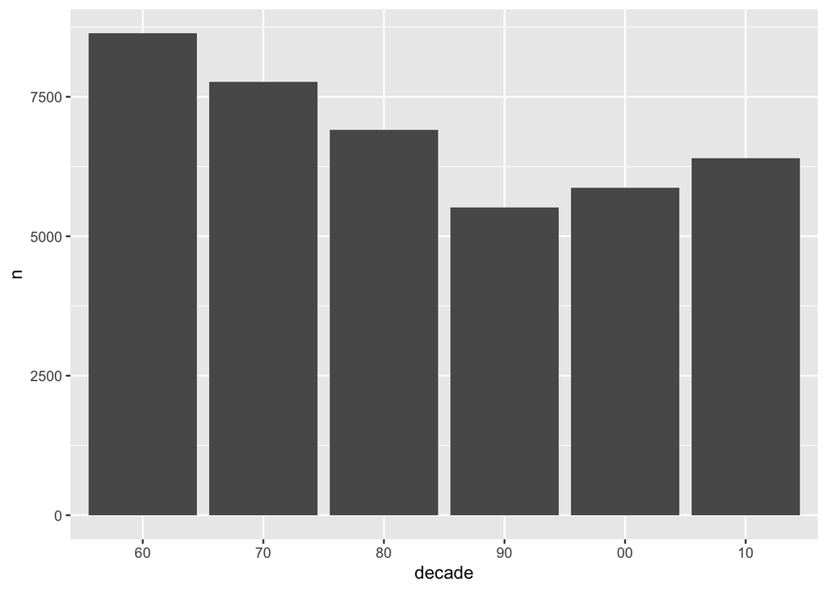

```r
song_df %>%
  group_by(decade) %>%
  count -> freq
  ggplot(freq) + geom_bar(stat= "identity",aes(x=decade,y = n),position = "dodge")
```

#how many songs in each decade

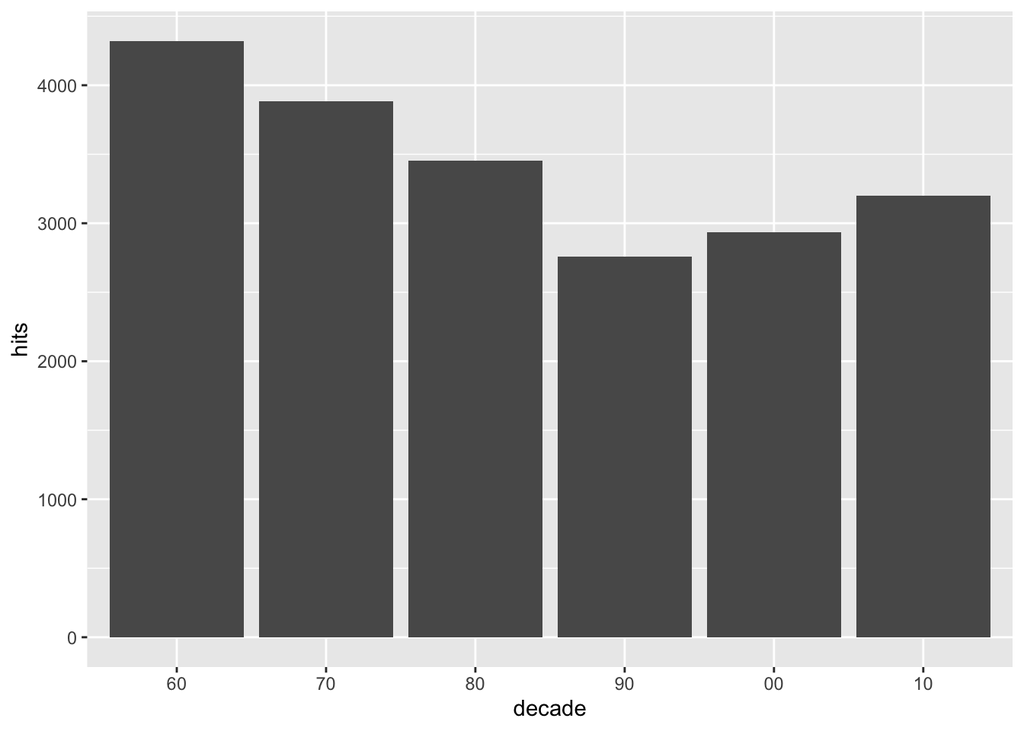

```r
plot_total_hits_by_decade <- function(df,col){

  plotting <- df %>% group_by(decade) %>%
    summarise(hits=sum({{col}}))
  ggplot(plotting) + geom_bar(stat= "identity",aes(x=decade,y = hits))
}
song_df %>% plot_total_hits_by_decade(target)
```

hits per decade This graph looks at the total amount of hits per decade. This is relevant because it shows that there was more variance in terms of how many different songs were hits. Leads to questions of how many different artists had hits to see if popularity of artists determined the amount of hits.

random forest new chunk to prevent the constant running of previous chunk based off of our predictions we have an 80% accuracy on unseen data

```r
song_df %>%
  select(-c(artist,mode,sections,time_signature)) %>%
  mutate(target = as.factor(target))-> update_song_df
  training_data <- update_song_df %>%
    filter(decade!="10")
  testing_data <- update_song_df %>%
     filter(decade=="10")
data_recipe <- training_data %>% recipe(target~.) %>%
  step_corr(all_numeric()) %>%
  step_center(all_numeric(),-all_outcomes()) %>%
  step_scale(all_numeric(),-all_outcomes()) %>%
  prep()

data_testing <- data_recipe %>%
  bake(testing_data)
data_training <- juice(data_recipe)
```

filteres specific entities. Using tidymodel,

Training data: 60s - 00s Test data: 10s

Recipe is data preprocessing

everything else is making sure that data is being procesed correctly

```r
r_forest <- rand_forest(trees = 100, mode = "classification") %>%
  set_engine("randomForest") %>%
  fit(target~., data = data_training)

r_forest %>%
  predict(data_testing) %>%
  bind_cols(data_testing) -> predictions_r_forest
  predictions_r_forest %>%
    metrics(truth = target,estimate = .pred_class)
```

```
## # A tibble: 2 x 3
##   .metric  .estimator .estimate
##   <chr>    <chr>          <dbl>
## 1 accuracy binary         0.790
## 2 kap      binary         0.579
```

Using random forest

Assertion: based off of a random forst model with 100 trees, there is a 79% accuracy.

## Multiple Logistic Regression

```r
mus = read.csv("song_df.csv") #read song dataset to variable mus



musiclog = mus[,-c(1,2,3,4)]#removing the  X ,track,artist,uri as these cannot be modelled

#summary of dataset
summary(musiclog)
```

```
##   danceability        energy              key            loudness
##  Min.   :0.0000   Min.   :0.000251   Min.   : 0.000   Min.   :-49.253
##  1st Qu.:0.4200   1st Qu.:0.396000   1st Qu.: 2.000   1st Qu.:-12.816
##  Median :0.5520   Median :0.601000   Median : 5.000   Median : -9.257
##  Mean   :0.5397   Mean   :0.579545   Mean   : 5.214   Mean   :-10.222
##  3rd Qu.:0.6690   3rd Qu.:0.787000   3rd Qu.: 8.000   3rd Qu.: -6.374
##  Max.   :0.9880   Max.   :1.000000   Max.   :11.000   Max.   :  3.744
##       mode         speechiness       acousticness    instrumentalness
##  Min.   :0.0000   Min.   :0.00000   Min.   :0.0000   Min.   :0.00000
##  1st Qu.:0.0000   1st Qu.:0.03370   1st Qu.:0.0394   1st Qu.:0.00000
##  Median :1.0000   Median :0.04340   Median :0.2580   Median :0.00012
##  Mean   :0.6934   Mean   :0.07296   Mean   :0.3642   Mean   :0.15442
##  3rd Qu.:1.0000   3rd Qu.:0.06980   3rd Qu.:0.6760   3rd Qu.:0.06125
##  Max.   :1.0000   Max.   :0.96000   Max.   :0.9960   Max.   :1.00000
##     liveness         valence           tempo        duration_ms
##  Min.   :0.0130   Min.   :0.0000   Min.   :  0.0   Min.   :  15168
##  1st Qu.:0.0940   1st Qu.:0.3300   1st Qu.: 97.4   1st Qu.: 172928
##  Median :0.1320   Median :0.5580   Median :117.6   Median : 217907
##  Mean   :0.2015   Mean   :0.5424   Mean   :119.3   Mean   : 234878
##  3rd Qu.:0.2610   3rd Qu.:0.7680   3rd Qu.:136.5   3rd Qu.: 266773
##  Max.   :0.9990   Max.   :0.9960   Max.   :241.4   Max.   :4170227
##  time_signature    chorus_hit        sections          target
##  Min.   :0.000   Min.   :  0.00   Min.   :  0.00   Min.   :0.0
##  1st Qu.:4.000   1st Qu.: 27.60   1st Qu.:  8.00   1st Qu.:0.0
##  Median :4.000   Median : 35.85   Median : 10.00   Median :0.5
##  Mean   :3.894   Mean   : 40.11   Mean   : 10.48   Mean   :0.5
##  3rd Qu.:4.000   3rd Qu.: 47.63   3rd Qu.: 12.00   3rd Qu.:1.0
##  Max.   :5.000   Max.   :433.18   Max.   :169.00   Max.   :1.0
##      decade
##  Min.   : 0.00
##  1st Qu.:10.00
##  Median :60.00
##  Mean   :52.93
##  3rd Qu.:80.00
##  Max.   :90.00
```

## Correlation Analysis

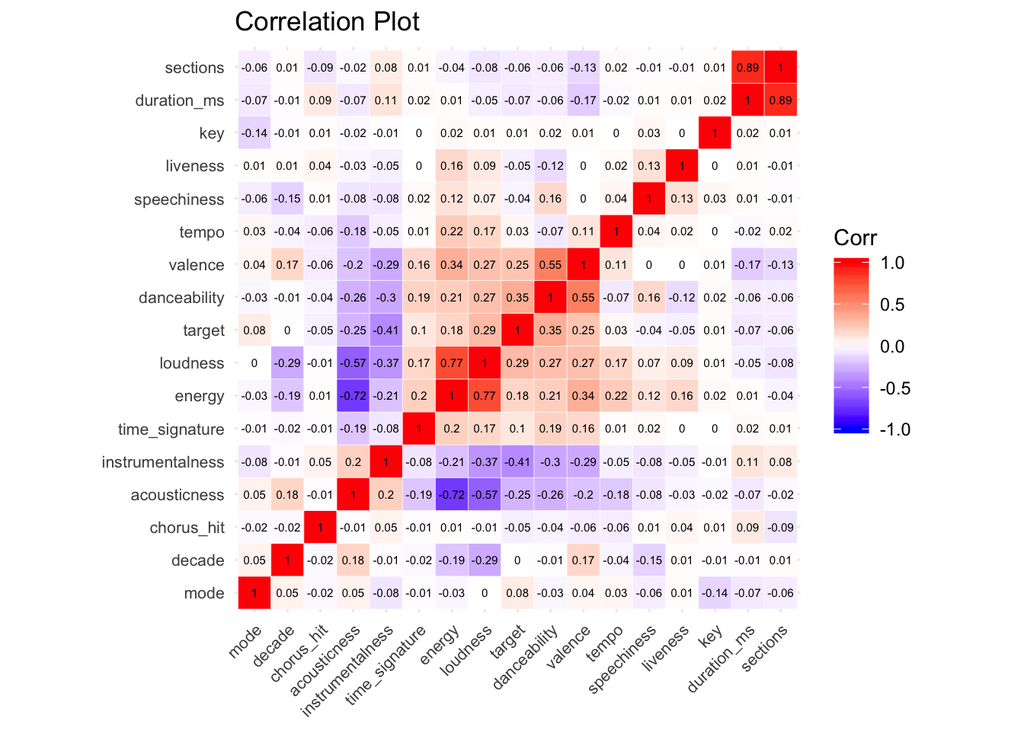

```r
musiclognum = musiclog%>% select_if(is.numeric)#selecting only the numeric variables from student for correlation

#Correlation plot from numeric variables
ggcorrplot(cor(musiclognum), hc.order = TRUE, outline.col = "white",lab = TRUE, title = "Correlation Plot", insig = c("pch", "blank"), pch = 4, pch.col = "black",lab_size = 2,tl.cex =8)
```

The correlation plot helps showcase the relationship between numeric variables. instrumentalness variable has the highest correlation(.41) with the Target variable, followed by danceability.

## Logistic Regression Model

```r
musiclog$decade = as.factor(musiclog$decade)#converting decade variable to factor
set.seed(123)#used to randomize the records in the dataset

train_set <- musiclog %>% filter(decade != "0" & decade != "10" )#training set obtained by filtering on data below 2000
train_set <-train_set[,-c(17)]

test_set <- filter(musiclog, decade == "0" | decade == "10")#testing set obtained by filtering on data from 2000 till now
test_set <-test_set[,-c(17)]
```

```r
logitreg <- glm(target~.,data = train_set, family = "binomial")#Creating a logistic regression model based on all the independent variables

#Model summary
summary(logitreg)
```

```
##
## Call:
## glm(formula = target ~ ., family = "binomial", data = train_set)
##
## Deviance Residuals:
##     Min       1Q   Median       3Q      Max
## -2.4256  -0.9734   0.1484   0.8928   3.4457
##
## Coefficients:
##                    Estimate Std. Error z value Pr(>|z|)
## (Intercept)       1.765e-01  1.993e-01   0.885 0.375914
## danceability      3.241e+00  1.135e-01  28.557  < 2e-16 ***
## energy           -7.369e-01  1.163e-01  -6.338 2.32e-10 ***
## key               1.311e-02  3.950e-03   3.319 0.000903 ***
## loudness          7.888e-02  5.157e-03  15.296  < 2e-16 ***
## mode              4.192e-01  3.138e-02  13.359  < 2e-16 ***
## speechiness      -5.854e+00  2.578e-01 -22.709  < 2e-16 ***
## acousticness     -1.332e+00  5.907e-02 -22.546  < 2e-16 ***
## instrumentalness -2.899e+00  7.005e-02 -41.384  < 2e-16 ***
## liveness         -1.586e-01  8.069e-02  -1.966 0.049320 *
## valence           3.581e-02  7.515e-02   0.476 0.633742
## tempo             2.507e-03  5.141e-04   4.876 1.08e-06 ***
## duration_ms       3.793e-07  2.995e-07   1.267 0.205253
## time_signature    5.386e-02  3.566e-02   1.511 0.130904
## chorus_hit       -2.368e-03  8.334e-04  -2.841 0.004490 **
## sections         -2.570e-02  7.320e-03  -3.511 0.000446 ***
## ---
## Signif. codes:  0 '***' 0.001 '**' 0.01 '*' 0.05 '.' 0.1 ' ' 1
##
## (Dispersion parameter for binomial family taken to be 1)
##
##     Null deviance: 39975  on 28835  degrees of freedom
## Residual deviance: 31260  on 28820  degrees of freedom
## AIC: 31292
##
## Number of Fisher Scoring iterations: 5
```

```r
predicttrain <- predict(logitreg,test_set,type = "response")#generating predicted output as a probability


Predicted_Result <- as.factor(ifelse(predicttrain > .6,1,0))#checking if predicted output is greater than 60% threshold and then assigning the target class(1/0)

#confusion matrix b/w predicted output and test data output
confusionMatrix(table(Predicted = Predicted_Result,Actual = test_set$target),positive = "1")
```

```
## Confusion Matrix and Statistics
##
##          Actual
## Predicted    0    1
##         0 4090 1076
##         1 2045 5059
##
##                Accuracy : 0.7456
##                  95% CI : (0.7378, 0.7533)
##     No Information Rate : 0.5
##     P-Value [Acc > NIR] : < 2.2e-16
##
##                   Kappa : 0.4913
##
##  Mcnemar's Test P-Value : < 2.2e-16
##
##             Sensitivity : 0.8246
##             Specificity : 0.6667
##          Pos Pred Value : 0.7121
##          Neg Pred Value : 0.7917
##              Prevalence : 0.5000
##          Detection Rate : 0.4123
##    Detection Prevalence : 0.5790
##       Balanced Accuracy : 0.7456
##
##        'Positive' Class : 1
##
```

A logistic regression model was created based on all the independant variables and the dependant variable Target(1/0).  
From the model summary it is clear that at 95% confidence interval all the independendant variables except - valence,time_signature and duration_ms were statistically significant in determining the Target(1/0). This was confirmed as the variables had p-value less than 0.05 thus rejecting the null hypothesis that coefficient = 0.

By keeping the cutoff for the Target variable to be considered as hit to .6 , a confusion matrix was created. The confusion matrix shows the model has an accuracy of 74.56% which is greater than the No - information rate. The confusion matrix also shows the sensitivity(82.46%) and specificity(66.6%) for the model.

## Variable Importance as Per T-Statistic

```r
#Creating a data frame showing variable importance in decreasing order of importnace based on T-statistic
imp <- as.data.frame(varImp(logitreg))
imp <- data.frame(Variable_names   = rownames(imp),overall_Importance_Tstat = imp$Overall)
imp[order(imp$overall,decreasing = T),]
```

```
##      Variable_names overall_Importance_Tstat
## 8  instrumentalness               41.3840144
## 1      danceability               28.5573344
## 6       speechiness               22.7093217
## 7      acousticness               22.5460476
## 4          loudness               15.2963470
## 5              mode               13.3585711
## 2            energy                6.3384545
## 11            tempo                4.8763534
## 15         sections                3.5111921
## 3               key                3.3191234
## 14       chorus_hit                2.8414806
## 9          liveness                1.9658120
## 13   time_signature                1.5105468
## 12      duration_ms                1.2667254
## 10          valence                0.4764667
```

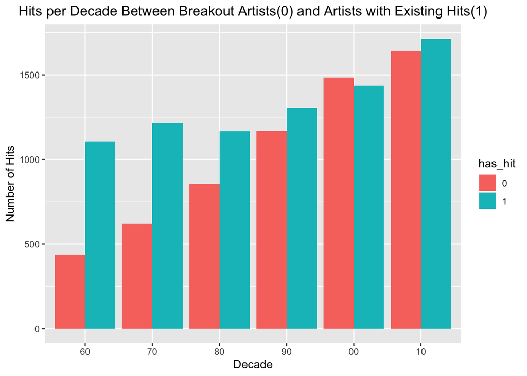

```r
song_df %>%
  group_by(decade,artist) %>%
  summarise(has_hit=max(target))%>%
  mutate(has_hit=as.factor(has_hit)) %>%
  group_by(decade,has_hit)%>%
  count -> hit_amount

ggplot(hit_amount) +
  geom_bar(stat="identity", aes(x=decade,y=n,fill=has_hit), position="dodge") +
  labs(title = "Hits per Decade Between Breakout Artists(0) and Artists with Existing Hits(1)", x = "Decade", y = "Number of Hits") +
  theme(plot.title = element_text(hjust = 0.5))
```

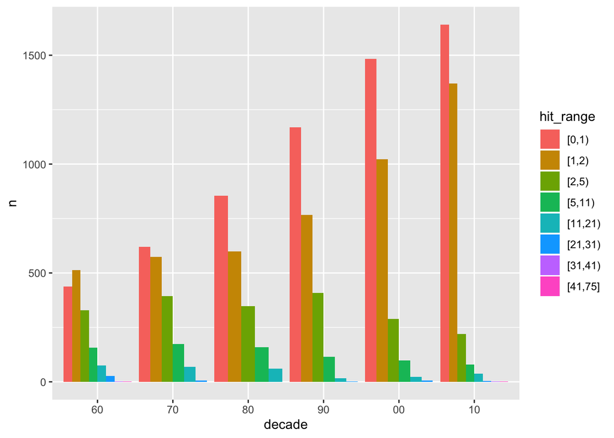

```r
song_df %>%
  group_by(decade,artist) %>%
  summarise(num_hits=sum(target))%>%
  mutate(hit_range=cut(num_hits,c(0,1,2,5,11,21,31,41,75),right=FALSE,include.lowest = TRUE))%>%
  group_by(decade,hit_range)%>%
  count -> tot_hit
ggplot(tot_hit) + geom_bar(stat="identity", aes(x=decade,y=n,fill=hit_range),position = "dodge")
```

```r
# %of hits from artists who already have one vs % of hits from those who don't(total artists with hits vs total hits starting from the second hit) --> try

#artist likelihood of having a previous hit affect liklihood of another song becoming a hit (when does the "takeoff happen) #how many hit songs (does it exponentially increase chances of having more) graph of total amount of hits vs how many artists have that many hits
```

#compares growth between ranges of hits. seeing how many hits an artist needs before they reach a certain amount of hits –> Stardom? break up this data more to get better precentages for determining the tipping point between “guaranteed hit”

#shows how many artists had how many hits on ranges in each decade.

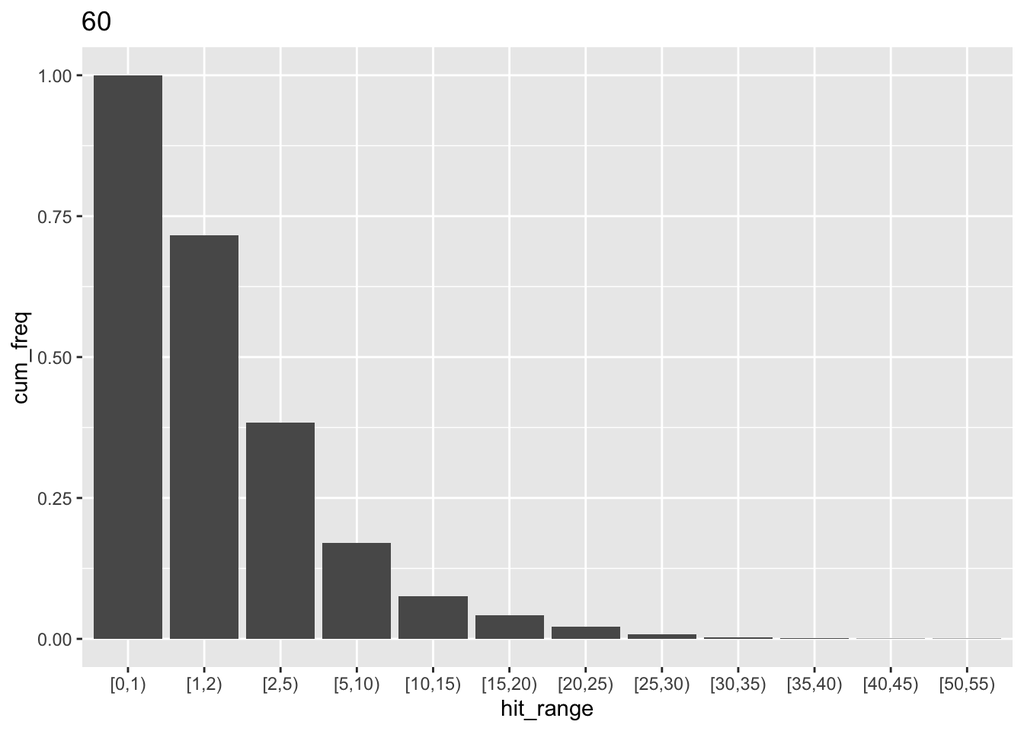

```r
song_df %>%
  group_by(decade,artist) %>%
  summarise(num_hits=sum(target))%>%
  mutate(hit_range=cut(num_hits,c(0,1,2,5,10,15,20,25,30,35,40,45,50,55,60,65,70,75),right=FALSE,include.lowest = TRUE))%>%
  group_by(decade,hit_range)%>%
  summarise(n=n()) %>%
  ungroup() -> mid_df

hit_ranges <- mid_df %>% ungroup() %>%
  distinct(hit_range) %>%
  mutate(join_var = 1)

decades <- mid_df %>%
  distinct(decade) %>%
  arrange(decade) %>% mutate(join_var = 1)
all_combo <- hit_ranges %>%
  inner_join(decades,by = "join_var") %>%
  select(-join_var)

all_combo %>%
  left_join(mid_df,by = c("decade","hit_range")) %>%
  replace_na(list(n=0)) %>%
  group_by(decade) %>%
  arrange(hit_range) %>%
  mutate(freq = n/sum(n),cum_freq = rev(cumsum(rev(freq)))) %>%
  ungroup() -> per_df


decades <- per_df %>%
  distinct(decade) %>%
  arrange(decade) %>%
  unlist() %>%
  unname()

plot_lst = list()
for (dec in decades) {
  plot_lst [[dec]] <- ggplot(per_df %>% filter(decade == dec)) + geom_bar(aes(x = hit_range,y=cum_freq), stat = "identity") + ggtitle(dec)
}
plot_lst[["60"]]
```

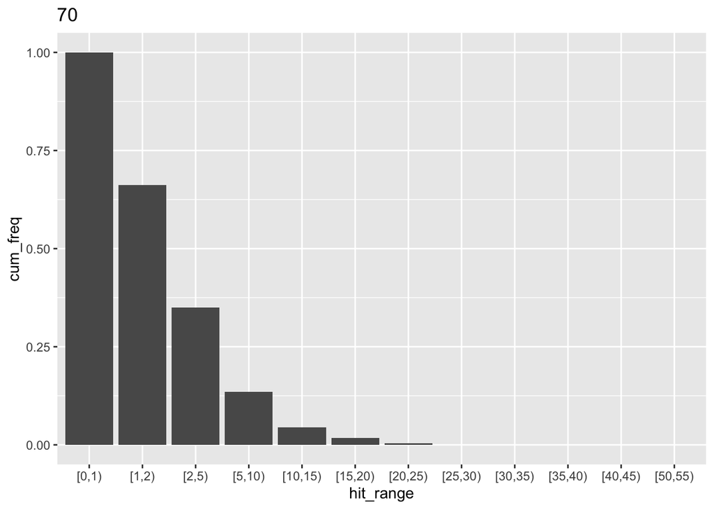

```r
plot_lst[["70"]]
```

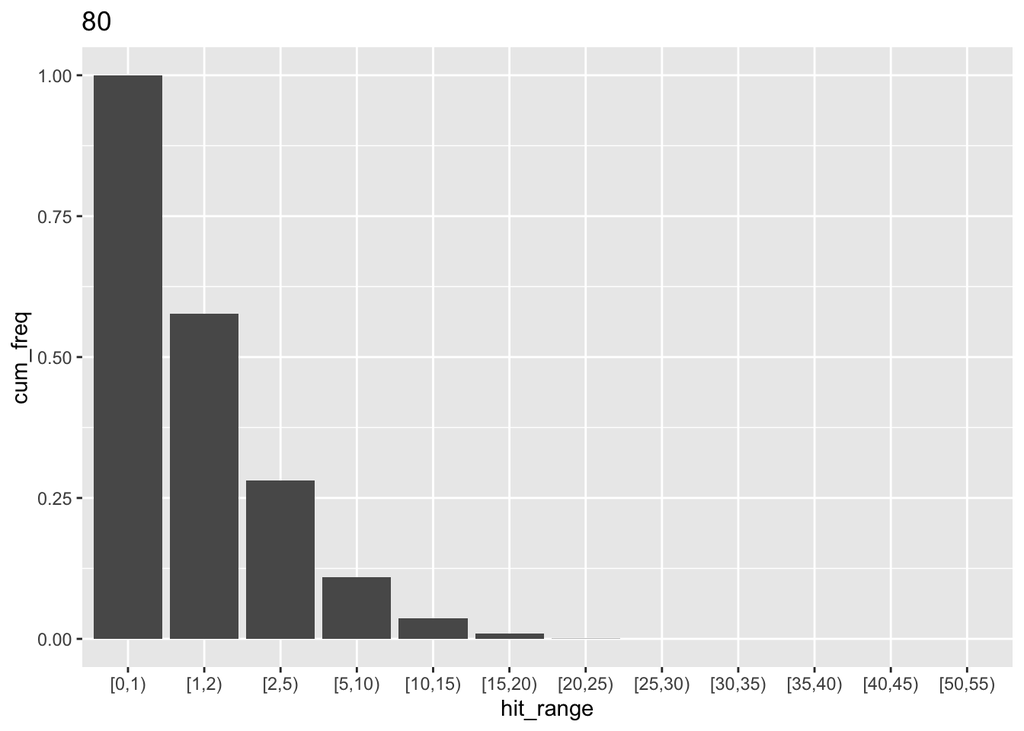

```r
plot_lst[["80"]]
```